# Analysis of World Castles

# Summary

In this analysis, we will explore the World Castle dataset from TidyTuesday. We will examine the distribution of castle categories across different countries, visualize their geographical locations, and analyze the timeline of castle construction. Additionally, we will take a closer look at some of the oldest structures in Hungary.

```r
library(tidyverse)
library(skimr)
library(ggimage)
```

# Read data

First, we will read the dataset from the provided URL.

```r
castles <- read_csv('https://raw.githubusercontent.com/rfordatascience/tidytuesday/main/data/2026/2026-09-01/world_castles.csv')
```

# Explore the data

Then, we will explore the structure and summary of the dataset using `glimpse()` and `skim()` functions.

```r
glimpse(castles)
```

```
Rows: 5,793
Columns: 15
$ qid         <chr> "Q12501", "Q2946", "Q80290", "Q1143049", "Q131013", "Q1332…
$ name        <chr> "Great Wall of China", "Palace of Versailles", "Forbidden …
$ category    <chr> "fortress", "palace", "palace", "castle", "fortress", "for…
$ country     <chr> "China", "France", "China", "France", "Greece", "Russia", …
$ iso         <chr> "CN", "FR", "CN", "FR", "GR", "RU", "ES", "GB-ENG", "DE", …
$ lat         <dbl> 40.43139, 48.80472, 39.91583, 47.21560, 37.97167, 55.75167…
$ lon         <dbl> 116.56444, 2.12028, 116.39083, 0.06220, 23.72611, 37.61778…
$ year        <dbl> -700, 1661, 1420, 990, -500, 1420, 1239, 1703, 1869, 1066,…
$ year_approx <dbl> 0, 0, 0, 0, 0, 0, 0, 0, 0, 0, 0, 0, 0, 0, 0, 0, 0, 0, 0, 0…
$ century     <chr> "7th century BC", "17th century", "15th century", "10th ce…
$ wikipedia   <chr> "https://en.wikipedia.org/wiki/Great_Wall_of_China", "http…
$ image       <chr> "https://commons.wikimedia.org/wiki/Special:FilePath/The%2…
$ sitelinks   <dbl> 192, 108, 104, 100, 96, 95, 95, 93, 91, 88, 86, 85, 82, 82…
$ pageviews   <dbl> 1441865, 756430, 666289, 11059, 542385, 375196, 576475, 73…
$ fame_rank   <dbl> 1, 2, 3, 430, 6, 10, 7, 5, 4, 8, 17, 9, 26, 16, 24, 12, 25…
```

```r
skim(castles)
```

Data summary

| Name | castles |
| --- | --- |
| Number of rows | 5793 |
| Number of columns | 15 |
| _______________________ |  |
| Column type frequency: |  |
| character | 8 |
| numeric | 7 |
| ________________________ |  |
| Group variables | None |

**Variable type: character**

| skim_variable | n_missing | complete_rate | min | max | empty | n_unique | whitespace |
| --- | --- | --- | --- | --- | --- | --- | --- |
| qid | 0 | 1.00 | 5 | 10 | 0 | 5793 | 0 |
| name | 0 | 1.00 | 3 | 60 | 0 | 5793 | 0 |
| category | 0 | 1.00 | 4 | 8 | 0 | 4 | 0 |
| country | 0 | 1.00 | 4 | 32 | 0 | 138 | 0 |
| iso | 5 | 1.00 | 2 | 6 | 0 | 136 | 0 |
| century | 2183 | 0.62 | 11 | 15 | 0 | 34 | 0 |
| wikipedia | 0 | 1.00 | 33 | 215 | 0 | 5793 | 0 |
| image | 0 | 1.00 | 70 | 604 | 0 | 5791 | 0 |

**Variable type: numeric**

| skim_variable | n_missing | complete_rate | mean | sd | p0 | p25 | p50 | p75 | p100 | hist |
| --- | --- | --- | --- | --- | --- | --- | --- | --- | --- | --- |
| lat | 0 | 1.00 | 41.88 | 14.73 | -53.63 | 37.18 | 46.17 | 50.51 | 81.72 | ▁▁▁▇▁ |
| lon | 0 | 1.00 | 23.48 | 43.92 | -175.20 | 3.56 | 14.40 | 28.98 | 174.79 | ▁▁▇▂▁ |
| year | 2183 | 0.62 | 1445.01 | 368.73 | -3000.00 | 1250.00 | 1500.00 | 1700.00 | 2009.00 | ▁▁▁▁▇ |
| year_approx | 0 | 1.00 | 0.09 | 0.28 | 0.00 | 0.00 | 0.00 | 0.00 | 1.00 | ▇▁▁▁▁ |
| sitelinks | 0 | 1.00 | 11.13 | 10.08 | 2.00 | 6.00 | 8.00 | 13.00 | 192.00 | ▇▁▁▁▁ |
| pageviews | 1 | 1.00 | 11719.36 | 42719.02 | 0.00 | 520.75 | 1969.00 | 7618.00 | 1441865.00 | ▇▁▁▁▁ |
| fame_rank | 0 | 1.00 | 2897.00 | 1672.44 | 1.00 | 1449.00 | 2897.00 | 4345.00 | 5793.00 | ▇▇▇▇▇ |

Let’s explore the distribution of castle categories and their counts by country.

```r
castles |>
    count(category)
```

```
# A tibble: 4 × 2
  category     n
  <chr>    <int>
1 castle    2591
2 fortress  1180
3 palace     934
4 ruin      1088
```

```r
castles |>
    count(country, sort = TRUE)
```

```
# A tibble: 138 × 2
   country            n
   <chr>          <int>
 1 France           351
 2 Italy            350
 3 Germany          349
 4 Japan            297
 5 Spain            230
 6 Poland           217
 7 Austria          182
 8 Czech Republic   182
 9 England          182
10 India            156
# ℹ 128 more rows
```

```r
country_by_cat <-
    castles |>
    count(category, country, sort = TRUE) |>
    group_by(country) |>
    mutate(all_n = sum(n)) |>
    ungroup() |>
    arrange(-all_n)

country_by_cat |>
    pivot_wider(names_from = category, values_from = n)
```

```
# A tibble: 138 × 6
   country        all_n castle palace  ruin fortress
   <chr>          <int>  <int>  <int> <int>    <int>
 1 France           351    145    100    59       47
 2 Italy            350    147    172    13       18
 3 Germany          349    164    103    63       19
 4 Japan            297    169      8   118        2
 5 Spain            230    166     39    13       12
 6 Poland           217    124     30    45       18
 7 Czech Republic   182     93     27    57        5
 8 England          182     84     18    73        7
 9 Austria          182     83     38    59        2
10 India            156      4     23    19      110
# ℹ 128 more rows
```

We can also visualize the density of buildings by country using a heatmap.

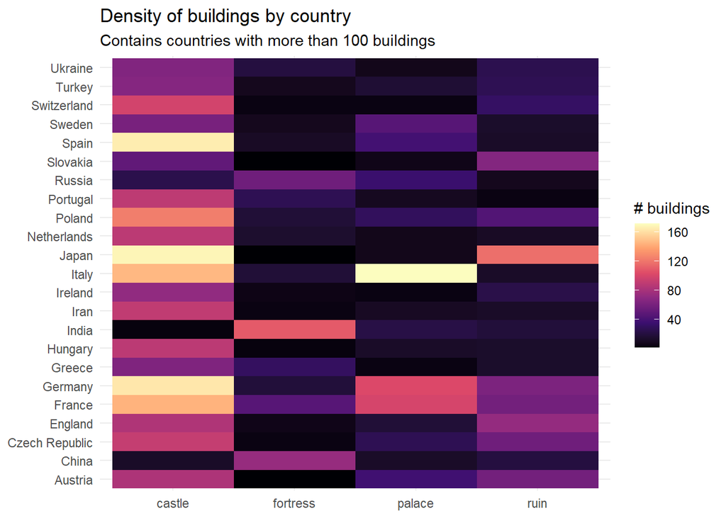

```r
country_by_cat |>
    filter(all_n > 100) |>
    ggplot() +
    aes(x = category, y = country, fill = n) +
    geom_tile() +
    labs(x = NULL, y = NULL, fill = "# buildings",
         title = "Density of buildings by country",
         subtitle = "Contains countries with more than 100 buildings") +
    theme_minimal() +
    scale_fill_viridis_c(option = "magma")
```

# Explore location of the castles

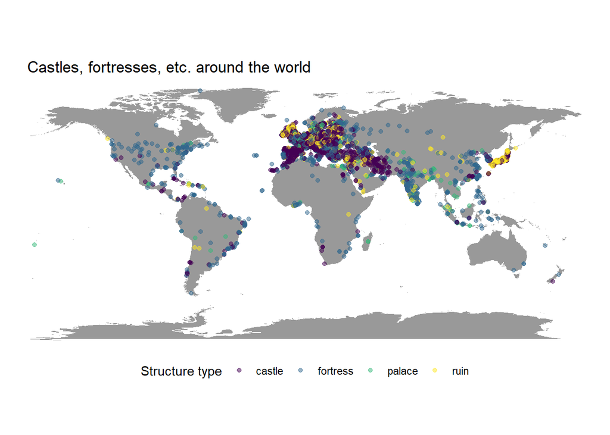

```r
world <- map_data("world")

ggplot() +
    geom_polygon(data = world, aes(x = long, y = lat, group = group),
                 fill = "gray60") +
    geom_point(data = castles, aes(x = lon, y = lat, color = category),
               alpha = .5) +
    scale_color_viridis_d() +
    coord_fixed() +
    theme_void() +
    labs(title = "      Castles, fortresses, etc. around the world",
         color = "Structure type") +
    theme(legend.position = "bottom")
```

# Explore the timeline

We can also explore the timeline of castle construction by creating a histogram of the years in which the castles were built.

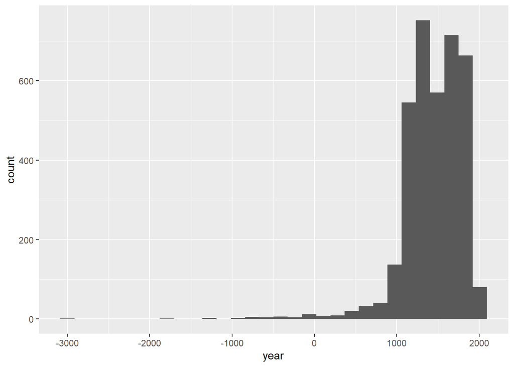

```r
castles |>
    ggplot() +
    aes(x = year) +
    geom_histogram()
```

# Structures from Hungary

Finally, we will take a closer look at some of the oldest structures in Hungary. We will filter the dataset for castles located in Hungary, arrange them by year, and visualize the oldest 10 structures using their images.

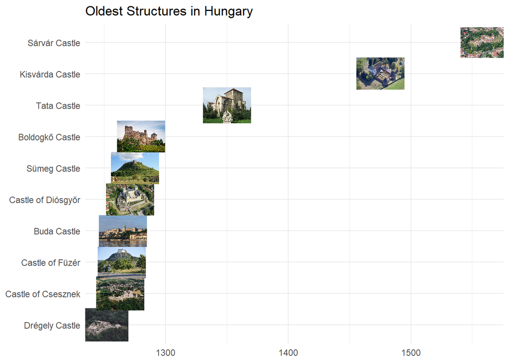

```r
castles |>
    filter(country == "Hungary") |>
    arrange(year) |>
    head(10) |>
    mutate(name = fct_reorder(name, year)) |>
    ggplot() +
    aes(x = year, y = name, image = image) +
    geom_image(size = .15) +
    labs(x = NULL, y = NULL, title = "Oldest Structures in Hungary") +
    theme_minimal()
```